# AI for Scientific Image Analysis

[figure not shown]

### *What works, what doesn't, and why*

A one-day workshop lecture for biologists with technical expertise.

*Part of the Competency Framework for AI in Scientific Image Analysis*

## Roadmap for the next 90 minutes

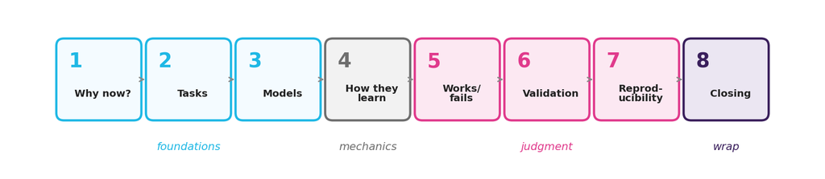

After the break, we walk through the afternoon labs.

## Section 1 — Why now?

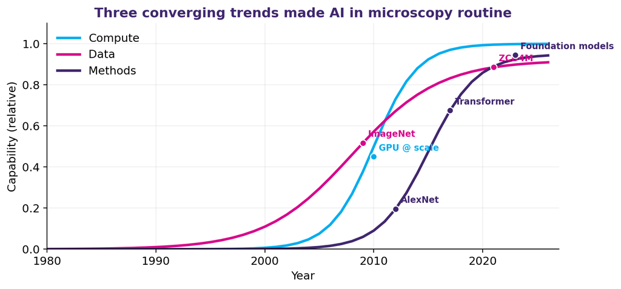

Why has AI become a routine tool in scientific imaging in the past decade, when image analysis has been a discipline for fifty years?

### Three drivers, all at once

- **Compute.** GPU availability and the scale shift from single-machine to cluster workflows.
- **Data.** Public datasets, image-sharing infrastructure, reusable training corpora.
- **Methods.** CNNs → vision transformers → foundation models. But methods don't matter without compute and data.

❓ *Framing claim, not a single citation.*

### Where the data and the tools live now

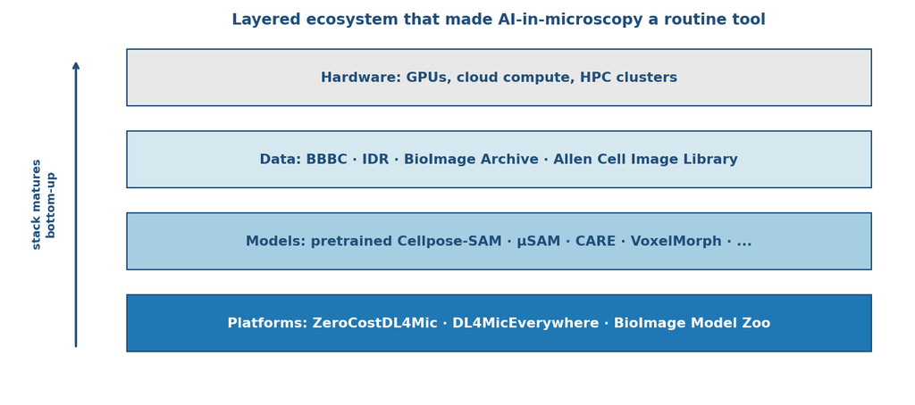

A non-exhaustive list of openly accessible infrastructure that made the data-and-tools driver real:

- **image.sc forum** — community discussion and resource hub <sup>[imagesc ✓]</sup> · forum.image.sc
- **Broad Bioimage Benchmark Collection (BBBC)** — curated benchmark datasets <sup>[bbbc2012 ✓]</sup>
- **NEUBIAS** — bioimage analyst training and resources <sup>[neubias ✓]</sup>
- **BioImage Archive, IDR, Allen Cell Image Library** — large-scale public imaging archives
- **ZeroCostDL4Mic** — Colab notebooks for the major DL microscopy methods, no install required
- **DL4MicEverywhere** — containerized successor; runs on Colab, local, HPC, cloud
- **[BioImage Model Zoo](https://github.com/bioimage-io/bioimage.io)** — standardized repository of pretrained DL models

Without infrastructure, data-hungry methods stay in single labs. **More in the Resources appendix at the end.**

## Section 2 — The image-analysis tasks AI addresses

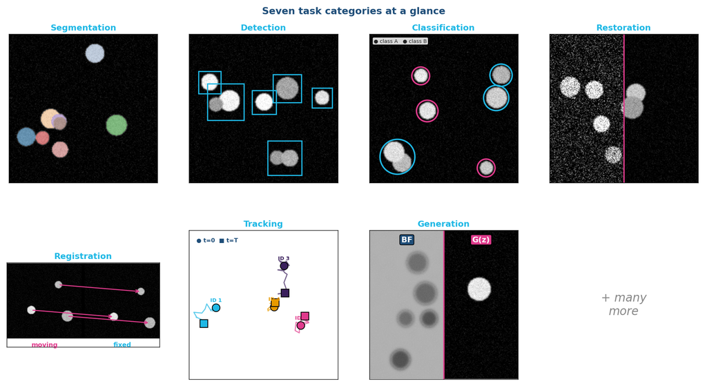

Seven major task categories. Most AI-imaging problems map to one or more.

### Task 1: Classification

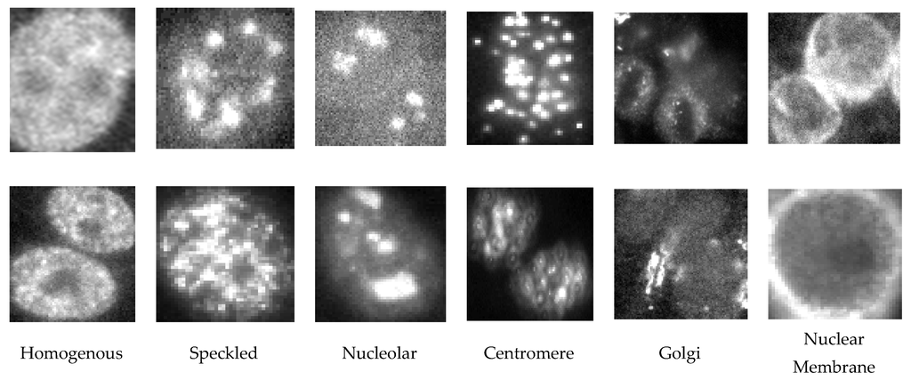

**What:** assign a label to an image or patch.

**Microscopy examples:** cell-cycle phase, phenotype call, mitosis-or-not. *Shown above:* the six classic HEp-2 anti-nuclear antibody staining patterns — input one image, output one category.

*Figure from Cascio, Taormina & Raso (2019), Applied Sciences 9(8):1618, [doi:10.3390/app9081618](https://doi.org/10.3390/app9081618). CC BY 3.0.*

### Task 2: Detection

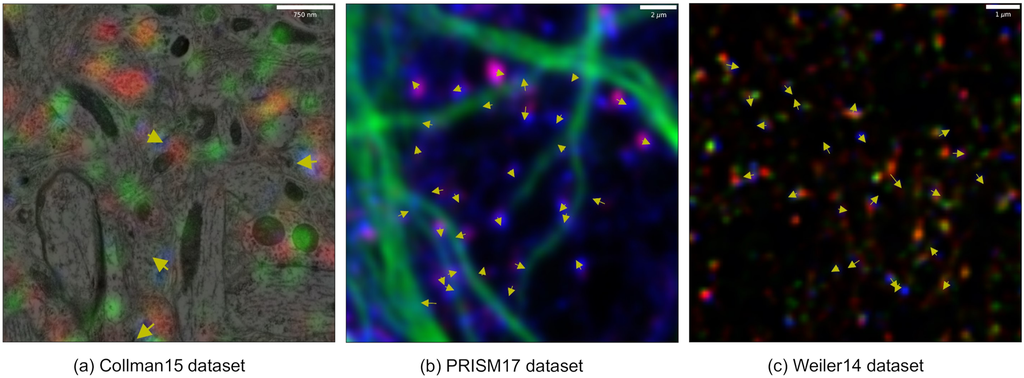

**What:** find objects and return bounding boxes or points.

**Microscopy examples:** spot detection (FISH spots, vesicles, **synapses** — shown above), particle picking. Yellow arrows mark detections across three multiplexed-fluorescence datasets.

**Method families:** classical (Laplacian-of-Gaussian) and learned (region proposals, transformers).

*Figure from Kulikov et al. (2019), PLOS Comput Biol 15(5):e1007012, [doi:10.1371/journal.pcbi.1007012](https://doi.org/10.1371/journal.pcbi.1007012). CC BY 4.0.*

### Task 3: Segmentation

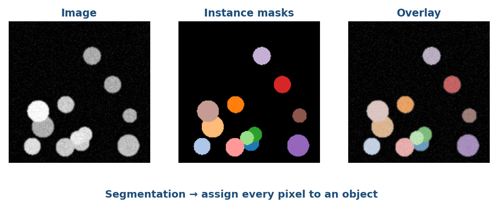

**What:** assign a label to every pixel; instance segmentation labels each object separately.

**Representative tools (live links):**

- **[Cellpose-SAM](https://github.com/MouseLand/cellpose)** — current v4 <sup>[cellpose_sam_2025 ⚠]</sup>; built on the original Cellpose framework <sup>[cellpose2021 ✓]</sup>
- **[StarDist](https://github.com/stardist/stardist)** — star-convex polygon segmentation <sup>[stardist2018 ✓]</sup>
- **[Mesmer / DeepCell](https://github.com/vanvalenlab/deepcell-tf)** — whole-cell segmentation <sup>[mesmer2022 ✓]</sup>
- **[Segment Anything](https://github.com/facebookresearch/segment-anything)** — foundation model <sup>[sam2023 ✓]</sup>
- **[μSAM (micro-sam)](https://github.com/computational-cell-analytics/micro-sam)** — microscopy-tuned SAM <sup>[microsam2025 ✓]</sup>

This is where most attendees first encounter AI in their work.

*Illustration synthesized for clarity; for a benchmark tissue panel see Greenwald et al. (2022) Mesmer, [Nat Biotechnol 40:555](https://doi.org/10.1038/s41587-021-01094-0).*

#### Drill-down — when Cellpose-SAM works

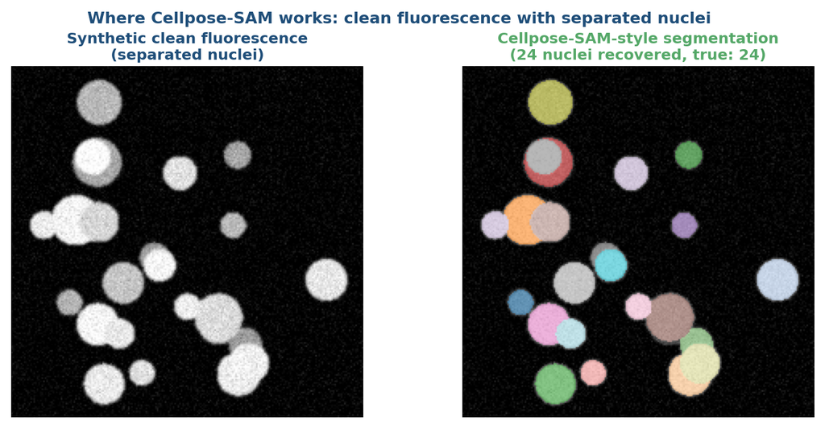

- **Strong cases:** cultured cells with clear morphology, nuclei in 2D, a sample type similar to Cellpose's training distribution.
- **Why:** the model was trained on 70,000+ segmented cells across many image types; the SAM backbone added in v4 brings strong zero-shot generalization.
- **What you do:** install Cellpose, point it at your image, accept the diameter estimate (or set it manually), inspect the output critically.

We'll do this hands-on in **Lab 1** this afternoon.

#### Drill-down — when Cellpose-SAM fails

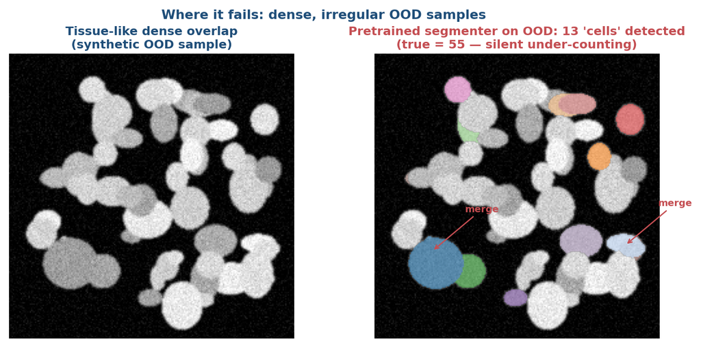

- **Weak cases:** unusual sample types (tissue when trained on cells), unusual staining patterns, dense overlapping objects, 3D when the third dimension is poorly sampled.
- **Failure signature:** confidently wrong masks, merged objects, missed objects near edges.
- **What you do:** try Cellpose's `nuclei` model instead of `cyto`, adjust diameter, consider StarDist or μSAM for a different inductive bias.

The same pattern shows up across all the segmentation tools — different inductive biases, different sample-type sweet spots.

### Task 4: Restoration

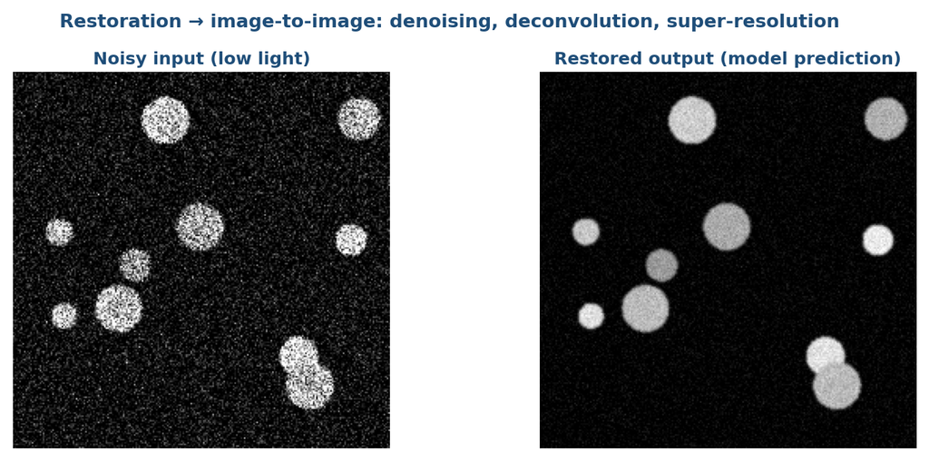

**What:** image-to-image transformation that improves quality — denoising, deconvolution, super-resolution.

**Representative tools (live links):**

- **[CARE / CSBDeep](https://github.com/CSBDeep/CSBDeep)** — content-aware restoration <sup>[care2018 ✓]</sup>
- **[Noise2Void](https://github.com/juglab/n2v)** — self-supervised denoising <sup>[noise2void2019 ✓]</sup>
- **ANNA-PALM** <sup>[annapalm2018 ✓]</sup> — super-resolution from sparse PALM
- **Deep-STORM** <sup>[deepstorm2018 ✓]</sup> — single-molecule localization
- The **Cellpose ecosystem** now integrates restoration with segmentation: Cellpose 3 <sup>[cellpose3_2025 ⚠]</sup> added one-click restoration; current Cellpose-SAM <sup>[cellpose_sam_2025 ⚠]</sup> carries the ecosystem forward
- All major restoration methods are available as Colab notebooks via **ZeroCostDL4Mic** and **DL4MicEverywhere**

⚠ *Restoration overlaps with generation. The line matters for image-integrity reporting — see Section 7.*

#### Drill-down — restoration's hallucination problem

- **The risk:** AI restoration changes pixel values. A denoised image isn't a measurement; it's a model's *prediction* of what the clean image looks like.
- **What that means in practice:** restored images can introduce features that weren't in the original signal — quietly, plausibly. This violates many journal image-integrity policies if not disclosed.
- **The honest path:** disclose AI restoration in figure captions, document the model identity and version, validate against ground truth where possible (we'll demonstrate this in Lab 3a if we choose option A).

This is the responsible-use spine of the lecture. Restoration is useful and risky in equal measure.

### Task 5: Generation

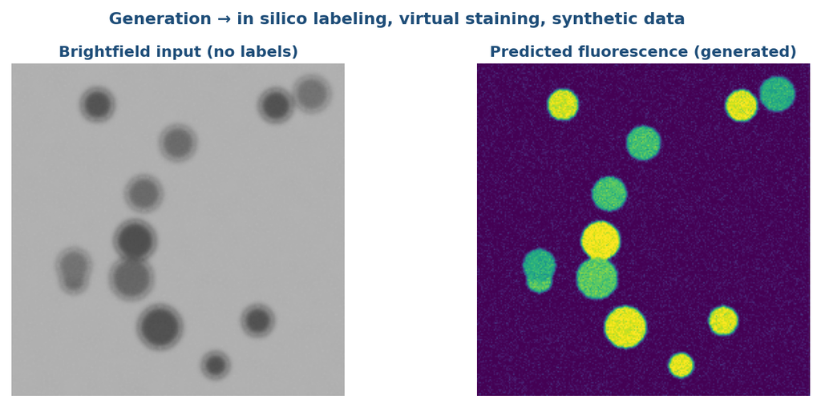

**What:** produce new image content from input or noise — virtual staining, in silico labeling, synthetic data.

**Representative work:** in silico labeling <sup>[christiansen2018 ✓]</sup>, label-free 3D prediction <sup>[ounkomol2018 ✓]</sup>.

❓ *Generation outputs are not measurements. The image-integrity considerations matter and we revisit them in Section 7.*

### Task 6: Registration

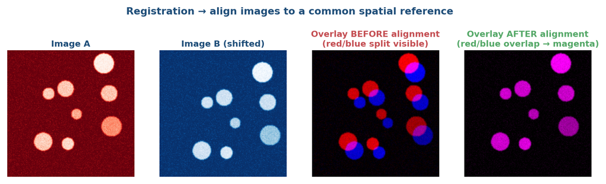

**What:** align images to a common spatial reference.

**Representative tools (live links):**

- **[VoxelMorph](https://github.com/voxelmorph/voxelmorph)** — deep-learning deformable registration; clinical-imaging foundational <sup>[voxelmorph2019 ✓]</sup>
- **BigStitcher** — terabyte-scale microscopy stitching (<sup>[bbbc2012 ⚠]</sup> for citation context; Hörl et al. 2019 *Nature Methods*)
- **ClearMap** — cleared-tissue volumetric registration with Allen Brain Atlas (Renier et al. *Cell* 2016)
- DL4MicEverywhere adds learned image registration as an explicit module

❓ *Microscopy-specific learned-registration tooling is fast-moving. Several methods overlap restoration and registration (e.g., learned drift correction).*

### Task 7: Tracking

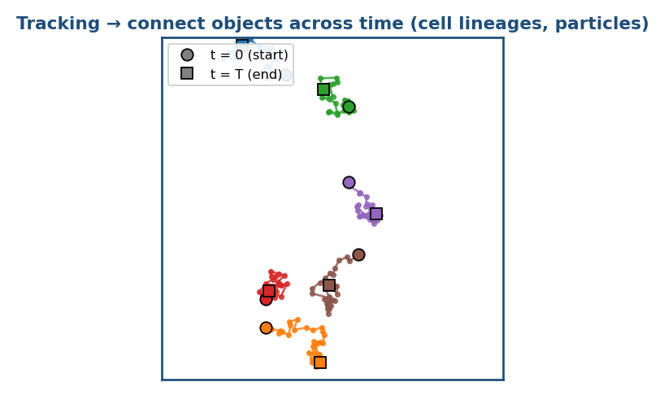

**What:** connect objects across time.

**Method families:** classical (Kalman, linear assignment) and learned (transformers, deep tracking).

*Illustration synthesized for clarity; for benchmark trajectories see Ershov et al. (2022) TrackMate 7, [Nat Methods 19:829](https://doi.org/10.1038/s41592-022-01507-1).*

## Section 3 — Common model families behind these tasks

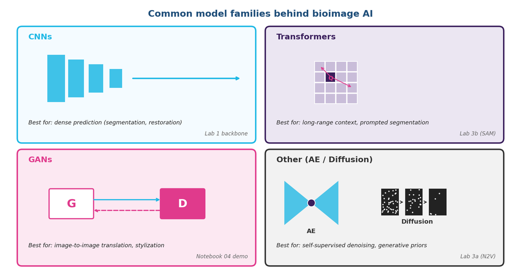

Most bioimage AI lives on three architecture families: **CNNs**, **Transformers**, and **GANs**. A fourth umbrella covers everything else worth recognizing — autoencoders, diffusion models, and the general encoder-decoder pattern.

You almost never pick the architecture directly. You pick a task and a tool; the tool's authors picked the architecture. Knowing the family tells you *why* a method has the strengths and weaknesses it does — and which lab in this workshop runs which.

### CNNs — Convolutional Neural Networks

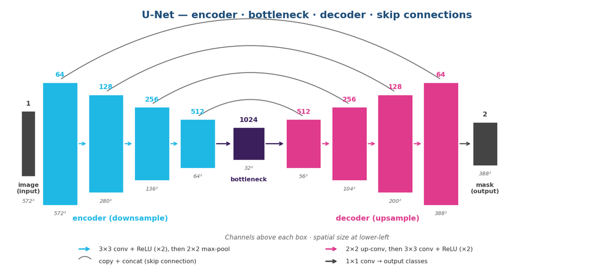

**Idea.** Stack of convolutions; each layer learns a small filter that slides over its input. Early layers pick up edges; deeper layers compose them. Translation-invariant by construction.

**Workhorses.** *U-Net* <sup>[unet2015 ✓]</sup> for image-to-image (segmentation, restoration). *ResNet* <sup>[resnet2016 ✓]</sup> for classification backbones. Encoder-downsample → decoder-upsample with skip connections is the dominant bioimage pattern.

**In this workshop.** Cellpose-SAM (CNN backbone + SAM transformer in v4); CARE, N2V, StarDist all U-Net-shaped.

| Strengths | Weaknesses |
| --- | --- |
| Mature ecosystem, vast pretrained weights, efficient inference, well-understood failure modes | Limited *global* context — single convolution sees a small neighborhood; stacked CNNs grow the field but never as cleanly as attention does |

### Transformers — global context via self-attention

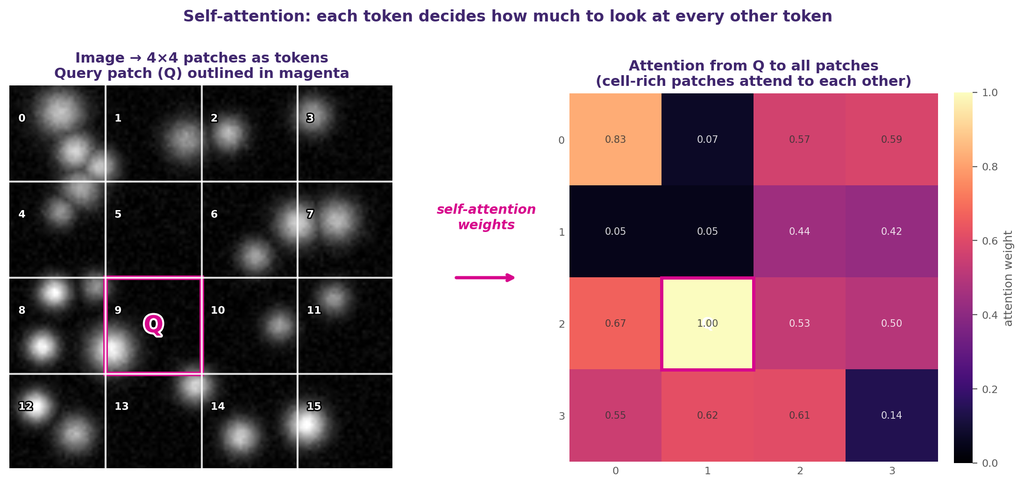

**Idea.** A *Vision Transformer* (ViT) <sup>[vit2021 ⚠]</sup> chops the image into patches, embeds each patch as a token, runs self-attention across all tokens. Captures long-range relationships natively, no convolution stack required.

**Foundation models.** Trained on huge unlabeled/weakly-labeled data, then *prompted* per task: SAM <sup>[sam2023 ✓]</sup>, μSAM (microscopy), BiomedCLIP (pathology), DINOv2 (general features). Largely a transformer paradigm.

**In this workshop.** Lab 3b: SAM/μSAM with point/box prompts. Cellpose-SAM is a hybrid (CNN backbone + SAM attention).

| Strengths | Weaknesses |
| --- | --- |
| Scales with data; strong few-shot; *prompting* — new task without retraining | Data-hungry from scratch; expensive at inference for large images; *prompt sensitivity* — the central pedagogy of Lab 3b |

### GANs — adversarial generation

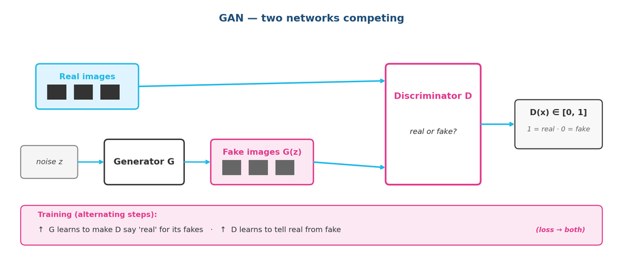

**Idea.** Two networks trained against each other. *Generator* tries to fool the *discriminator*; discriminator tries to tell real from generated. The game pushes the generator toward photorealistic output. Goodfellow et al. <sup>[gan2014 ✓]</sup>.

**Bioimage uses.** *pix2pix* <sup>[pix2pix2017 ✓]</sup> for paired image-to-image (brightfield → fluorescence; IHC → mIF; modality A → B). *CycleGAN* for *unpaired* translation. *StyleGAN* for unconditional generation (rare in bioimage; more common in medical-imaging data augmentation).

**In this workshop.** Notebook 04: pix2pix mini-workflow + CycleGAN catalog pointer.

| Strengths | Weaknesses |
| --- | --- |
| Photorealistic output; compact at inference; established literature | Training instability + *mode collapse*; **hallucination risk** — outputs that look correct but invent features. Disclose generation in figure captions. |

### Other architectures worth recognizing

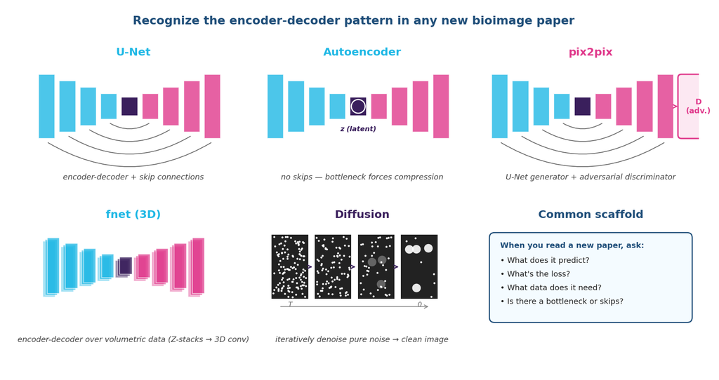

| Family | What it is | Bioimage relevance |
| --- | --- | --- |
| **Autoencoders** | Encoder → bottleneck → decoder; trained with reconstruction loss | *Noise2Void* <sup>[noise2void2019 ✓]</sup> (Notebook 03a); DINO, MAE for self-supervised features |
| **Diffusion models** | Generate by gradually denoising pure noise | *DDPM* <sup>[ddpm2020 ⚠]</sup>; **replacing GANs**; growing fast in bioimage. Curated [awesome-list for medical imaging](https://github.com/amirhossein-kz/Awesome-Diffusion-Models-in-Medical-Imaging). |
| **Encoder-decoder pattern** | The shared backbone | U-Net (with skips), autoencoders, pix2pix gen, fnet — recognize this in *every* new bioimage paper |

**Takeaway.** New architectures appear every year. The conceptual scaffold — *what does it predict, what's the loss, what data does it need* — is more durable than any architecture name.

## Section 4 — How models actually learn

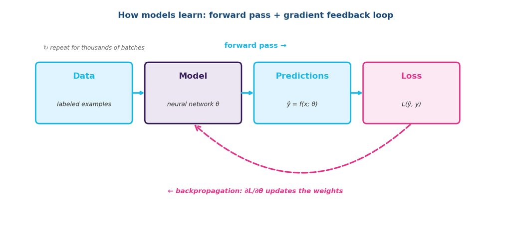

Conceptual scaffolding, not architecture details. We will not teach you what a U-Net is. We will teach you what it does and where it fails.

### Training, validation, and test data

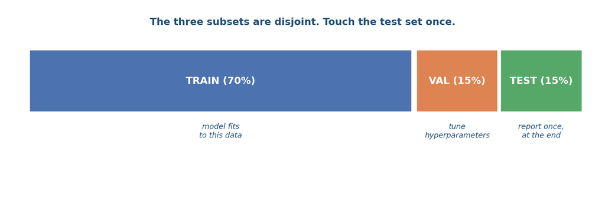

Three disjoint subsets of your data. Each has a different job.

- **Training set** — what the model fits to. The model sees these images and adjusts its parameters to minimize prediction error on them.
- **Validation set** — what you tune hyperparameters against. Used to choose between candidate models or settings *during* development.
- **Test set** — what you report on, **only after everything else is locked**. Touch it once, at the end. Touch it twice, and your reported accuracy is no longer trustworthy.

The biggest beginner mistake: tuning on the test set. The second biggest: letting training data leak into the test set (e.g., images from the same patient in both).

This split is the single most important pattern in supervised ML. Every method we discuss assumes it. ❓

### Loss and learning, conceptually

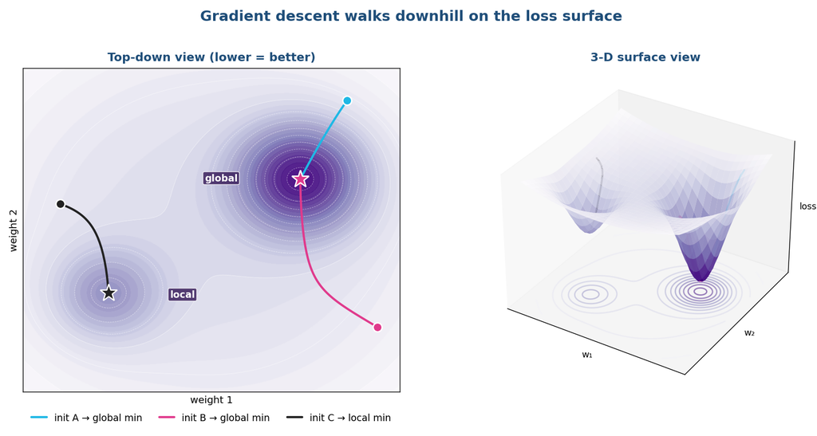

A model is a parametric function — millions or billions of numbers (weights) that together compute "given this input image, predict this output."

**Training** adjusts those weights to reduce a *loss* — a single number that measures how wrong the model is on the training data. For segmentation, loss might be how many pixels were assigned the wrong label. For classification, how often the predicted class was wrong.

**Gradient descent** walks downhill on the loss surface. At each step, it computes which direction reduces the loss most, then takes a small step that way. Millions of steps later, the loss is low and the model is "trained."

This is the mental model. We do not need the math today, but the intuition matters: the model has done exactly one thing — it has reduced loss on training data. Whether that translates to your data is a separate question. ❓

### Generalization

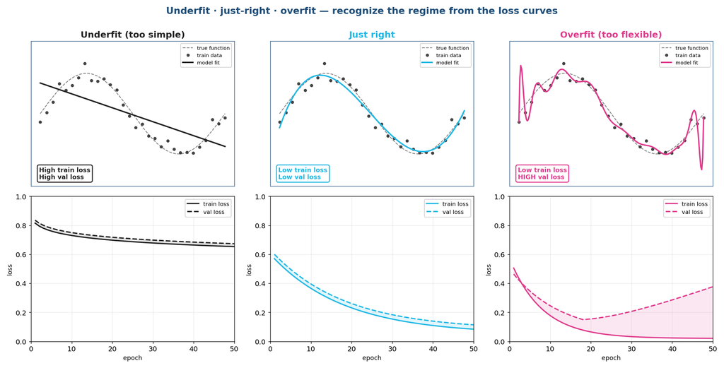

A model that does well on training data may do poorly on yours. This is *the* central problem in applied ML.

**Why generalization is hard:**

- Training data is finite; the world is not.
- Models can memorize training data (overfitting) without learning general patterns.
- The conditions under which the model was trained may not match the conditions under which you use it (distribution shift).

**The single most important variable:** the *diversity* of training data relative to the diversity of your data. A Cellpose model trained on 70,000 cells across many image types generalizes well across cell biology because the diversity is broad. The same model fails on a histology section because that diversity didn't include tissue.

Generalization is what every AI-imaging failure mode in Section 5 is, at root, an instance of. ❓

### Three modes of use today

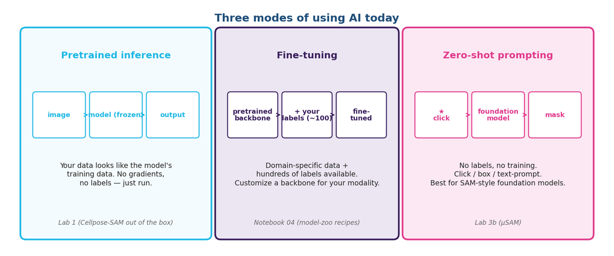

- **Pretrained inference** — use someone else's model on your data. Lab 1.
- **Fine-tuning** — adjust a pretrained model with your own labels.
- **Zero-shot / prompt-based** — foundation models with prompts, no fine-tuning.

The afternoon labs will exercise pretrained inference (Lab 1) and either self-supervised denoising (Lab 3a) or prompt-based foundation models (Lab 3b).

❓ *Workshop-specific framing.*

### Go deeper — learn the mechanics

Two outstanding free resources that build the same intuition we just sketched, with much more depth:

- **3blue1brown — "Neural Networks" series** (visual, low-math, ~1 hour total). Four short videos covering what a neural network is, gradient descent, and backpropagation — the same forward-and-backward loop we walked through above. [3blue1brown.com/topic/neural-networks](https://www.3blue1brown.com/?topic=neural-networks)
- **TensorFlow Playground** — a tiny neural network you can train *in your browser*. Pick a 2-D dataset, watch the loss curve drop in real time, see hidden-unit activations evolve. Zero install, instant feedback. playground.tensorflow.org

If gradient descent still feels abstract after this lecture, an evening with these two is worth more than reading another paper.

## Section 5 — When AI works, and when it doesn't

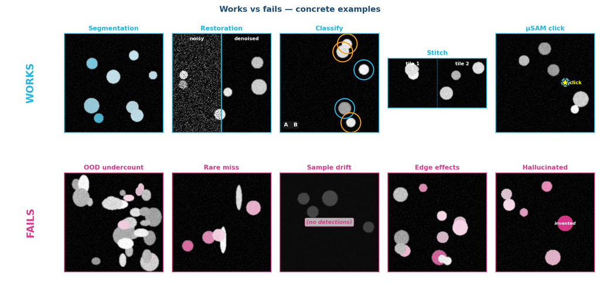

### Where it currently works well

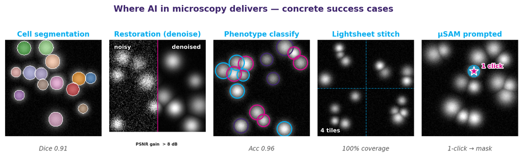

Concrete examples of well-validated successes:

- **Segmentation** of cell types similar to training data — Cellpose-SAM and Mesmer routinely achieve >0.85 Dice on standard cell-line and tissue panels they were trained for.
- **Denoising** of structured noise patterns the model has been exposed to — CARE-restored fluorescence images approach the SNR of long-exposure references with 10–100× less light.
- **Classification** of well-defined categories with thousands of training examples — phenotypic profiling at high-content-screening scale.
- **Stitching** of multi-tile microscopy when overlap is consistent and contrast is reliable — BigStitcher routinely handles terabyte-scale lightsheet data.
- **Foundation-model segmentation** on novel sample types via prompts — μSAM extends segment-anything's reach into microscopy with a few clicks per image.

The pattern: AI works well when training data covers the use case, and when validation has been done on data similar to yours. ❓

### Where it fails

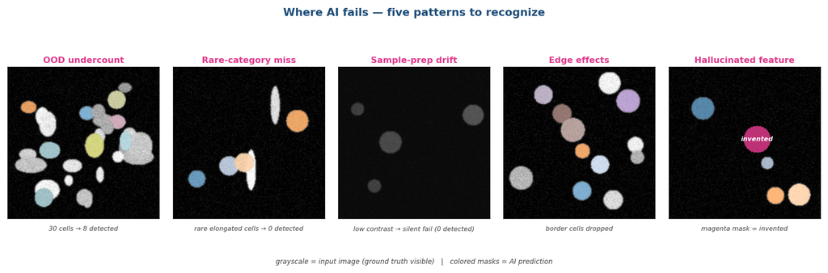

Concrete failure patterns:

- **Out-of-distribution samples** — a Cellpose model trained on cultured cells producing confident-but-wrong masks on tissue. A clinical-AI tool trained on a US population mis-classifying scans from a different scanner brand.
- **Sparse or rare categories** — anything underrepresented in training. Rare disease presentations, atypical cell shapes, sample-preparation variants the model never saw.
- **Sample-preparation drift** — the model sees a population the training set didn't. Even small changes in fixation, mounting, or staining can degrade performance silently.
- **Edge effects** — many segmentation tools struggle at image borders or near other objects.
- **Hallucination in restoration and generation** — outputs that look right but contain features the model invented.

We'll see the segmentation failure mode directly in Lab 1, and (if option A) the restoration hallucination directly in Lab 3a. ❓

### Failure-mode patterns to recognize

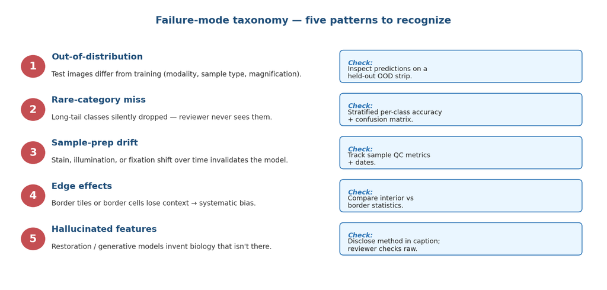

- **Domain shift.** Tools trained on one organism, modality, or stain often degrade on another.
- **Sample-preparation effects.** Fixation, mounting, staining drive failures the model has never seen.
- **Confident wrongness.** Outputs that look plausible but are wrong. The most dangerous mode.
- **Hallucination in generative methods.** Restoration and virtual staining can invent features.
- **Misregistration in alignment tasks.** Models can align some structures while distorting others, corrupting downstream measurements without an obvious signature.

❓ *Community-recognized failure-mode taxonomy; no single canonical citation.*

### Failure mode: domain shift

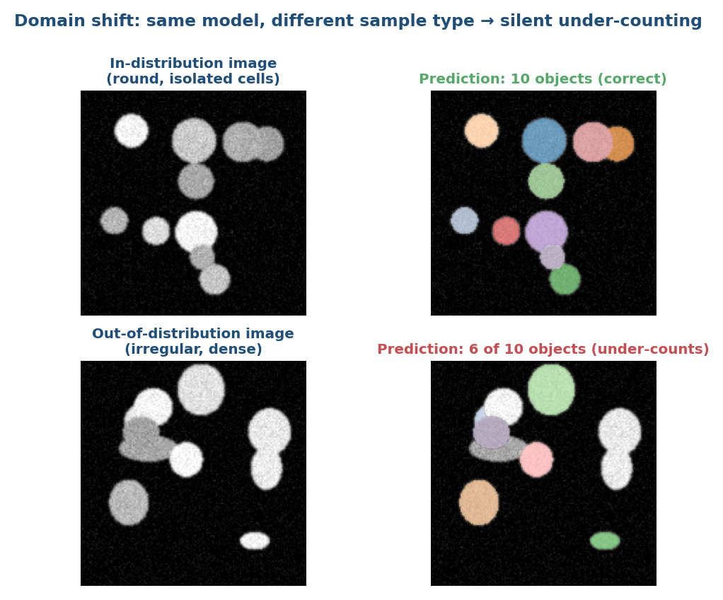

Same Cellpose model, different sample type. Round isolated cells: works. Irregular dense cells: silent under-counting. Failure looks plausible — that's the dangerous part.

*Illustration synthesized for clarity; for quantitative cross-dataset generalization benchmarks see Pachitariu, Rariden & Stringer (2025) Cellpose-SAM, [bioRxiv 2025.04.28.651001](https://doi.org/10.1101/2025.04.28.651001) and Stringer et al. (2021) Cellpose, [Nat Methods 18:100](https://doi.org/10.1038/s41592-020-01018-x).*

### Failure mode: hallucination in restoration

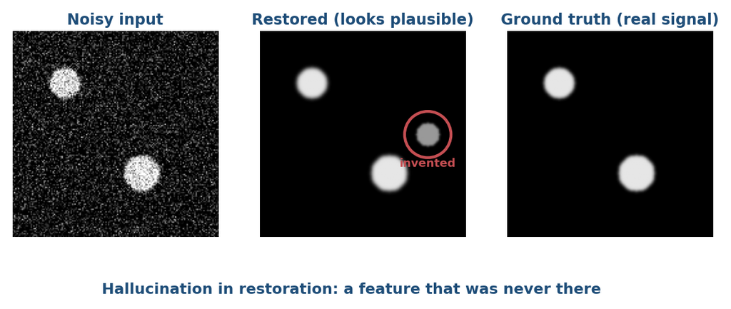

The restored image looks clean and plausible. But it contains a feature the model invented. Without the ground truth (which you don't have in real experiments), you cannot tell.